# R Notebook

# Advanced ggplot homework

```r
library(tidyverse)
library(CodeClanData)
library(ggthemes)
library(extrafont)
fonts()
```

[output not shown]

```r
col_scheme <- c("#E89FE9", "#50434F", "#B6A7B5", "#F9A472", "#BD7040")
company_theme <- theme_bw(base_size = 12, base_family = "Trebuchet MS") +
  theme(
        panel.border     = element_blank(),
        panel.background = element_rect(fill   = "white",  colour = "white"),
        panel.grid.major = element_line(colour = "grey95", size   = 0.5),
        panel.grid.minor = element_line(colour = "grey95", size   = 0.5)
)
```

1. Take the data in the dataset qb_revenue_breakdown and make a stacked bar chart showing the sources of revenue across the two years in the dataset.

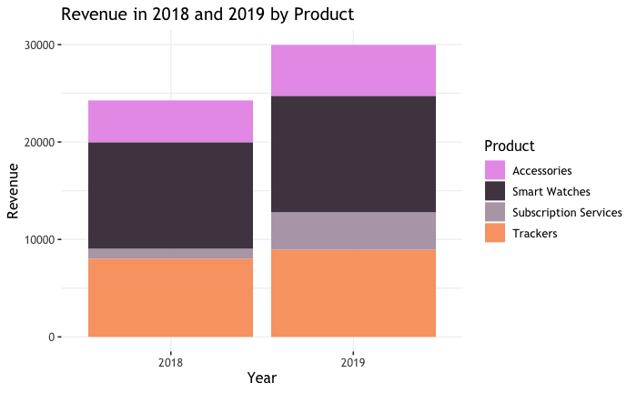

2. Make a line chart showing monthly sales of the “flagship product” - the KwikBit Unit1 - over the last year. This data is inside qb_monthly_sales, but you will need to use subset.

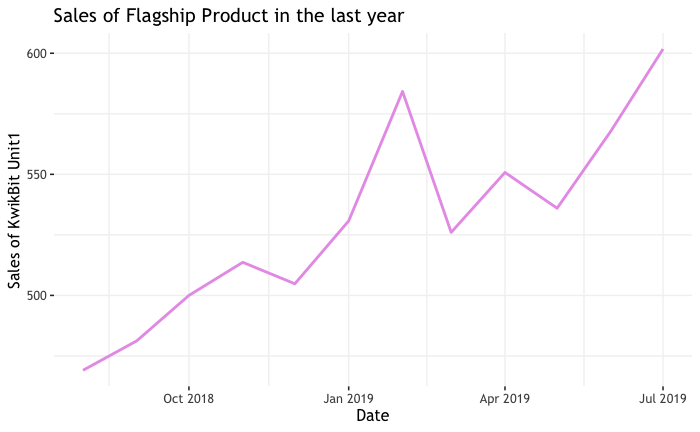

3. Make a line chart showing monthly revenue and costs over the last year. This data is also in qb_monthly_sales.

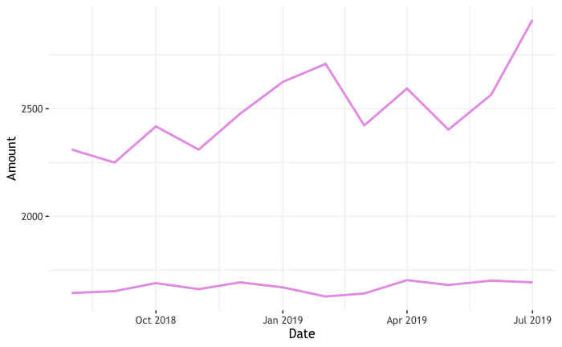

4. Show annual sales of personal fitness trackers over the last 5 years broken down by company as a ribbon plot (use geom_area). This data is in qb_competitors.

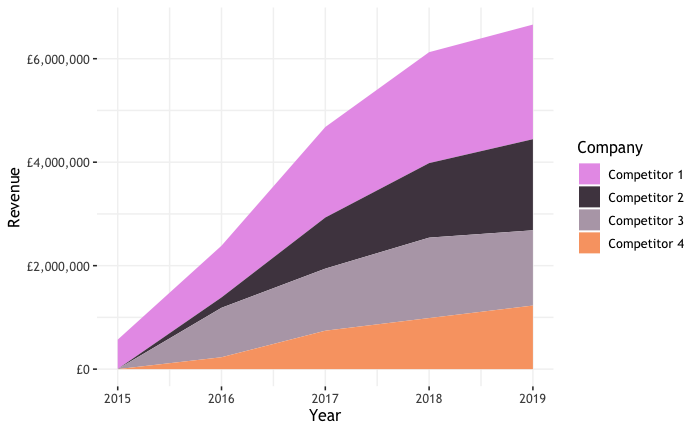

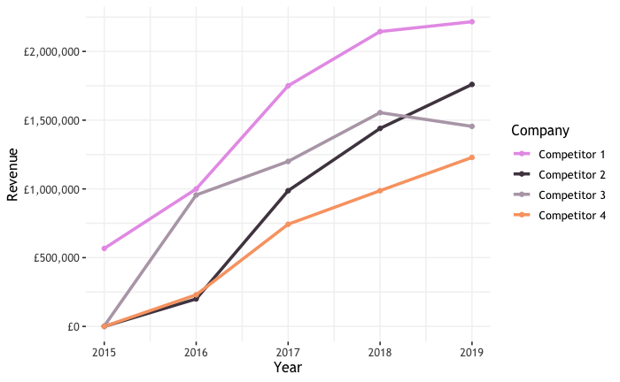

6. Now the company wants to compare the number of steps that their device counts vs. their competitors. Make a line graph of the number of steps throughout time, and use faceting to compare between individuals and devices. Data is in qb_device_data.

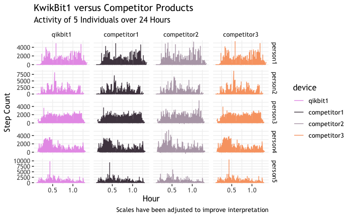